# HNET analysis

Philipp Chapkovski

Higher School of Economics  
fchapkovskiy@hse.ru

05 January, 2021

## Introduction

This data was downloaded from https://www.h-net.org/jobs and parsed into a relational database using Python and Django. Parser is available here and the most recent version of the database is available [here](https://osf.io/3sb52/). The code for analysis is [here](https://github.com/chapkovski/hnet-analysis). In total for the last 20 years (starting from 2000 till December 31, 2020) a bit more than 38.000 job ads were posted at H-Net: on average about 1800 position per year.

Till recently about 2/3 of them were professorship positions (from Assistant to Full professor), but for the last 5 years these positions are in decline and in 2020 this amount dropped to below 45%.

## Posts per week per year

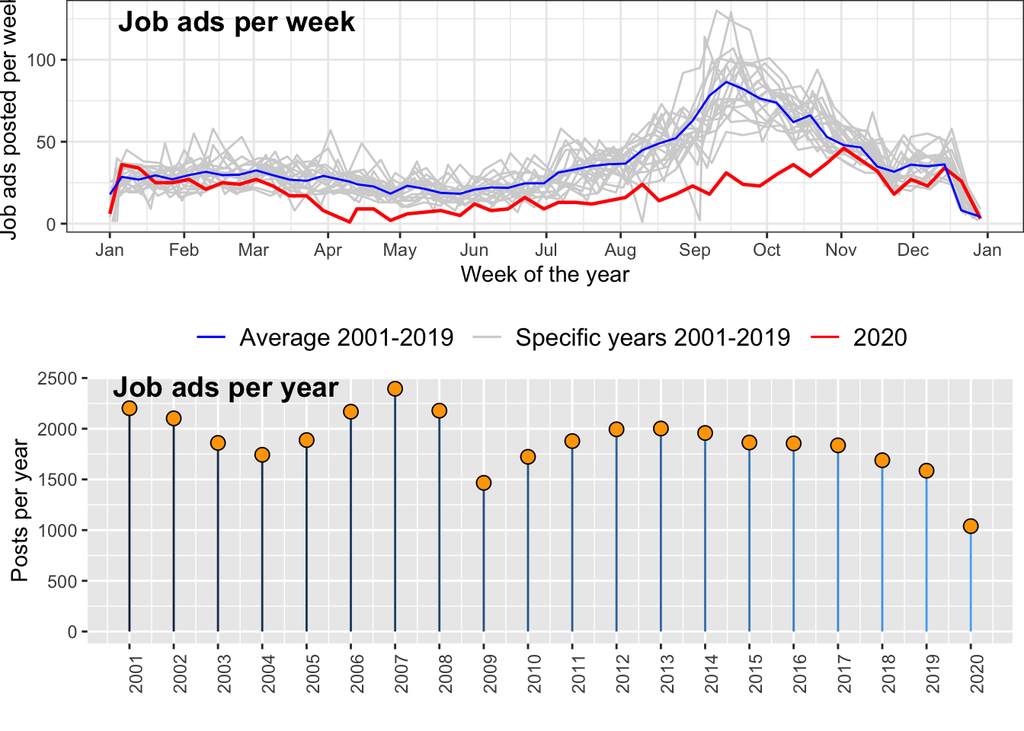

## Seasonality (posts per month)

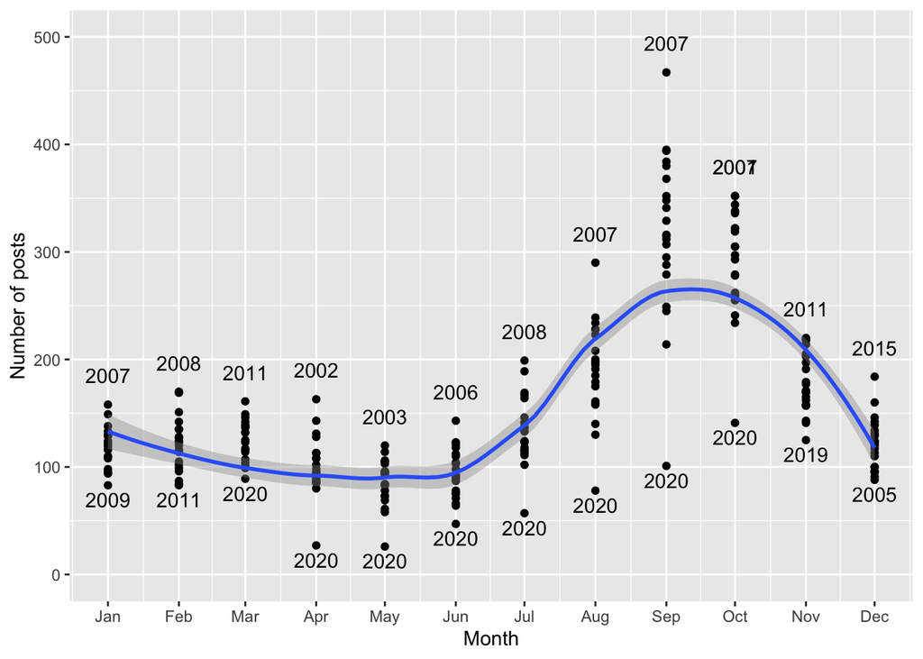

## Dynamics of professorship positions vs other positions

In the plot below percentages is a share of professorship positions in total number of job ads posted per year.

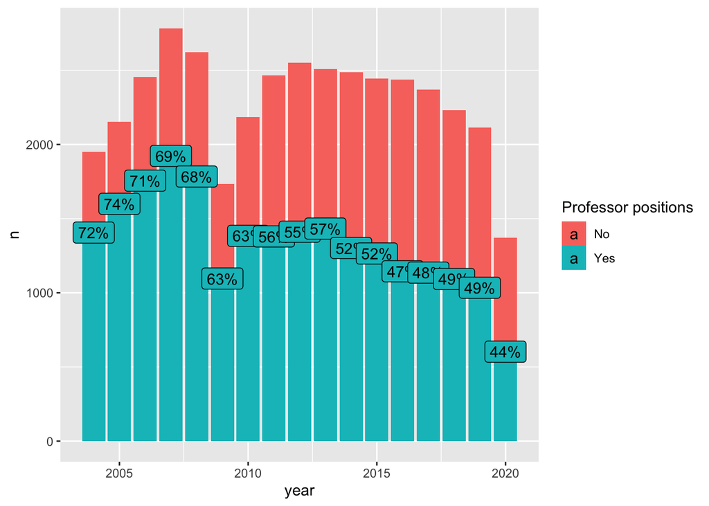

## Black studies/Race studies positions

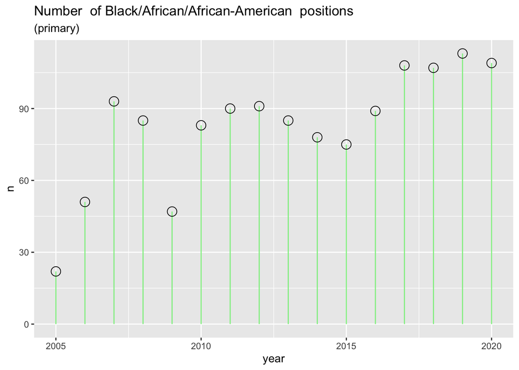

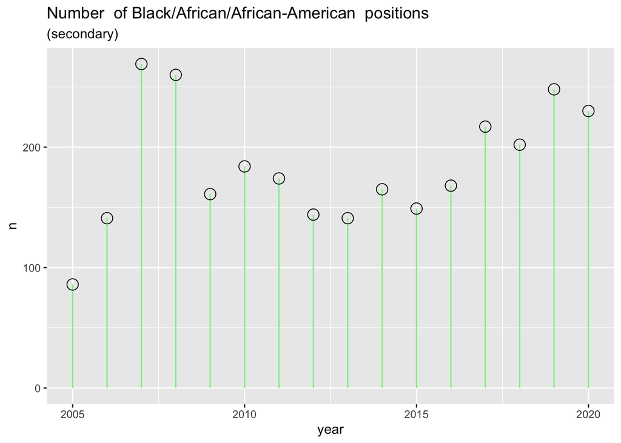

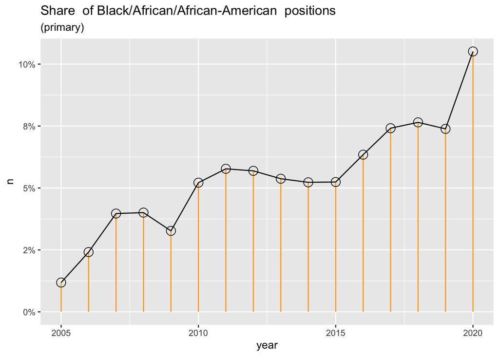

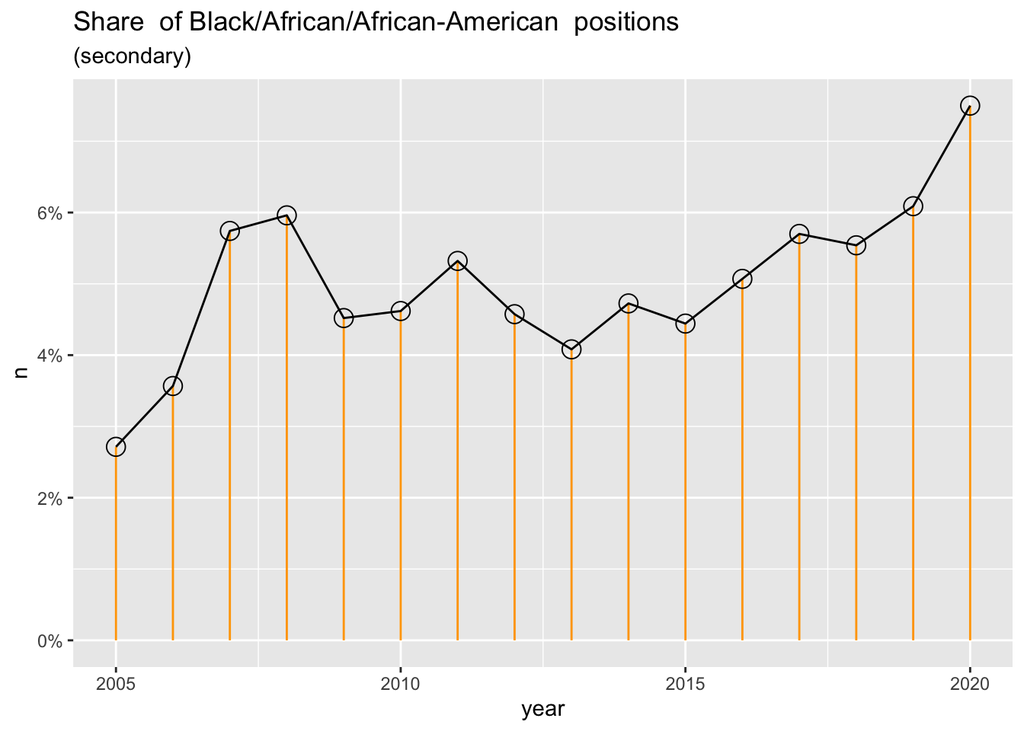

## Feminism/Women studies positions

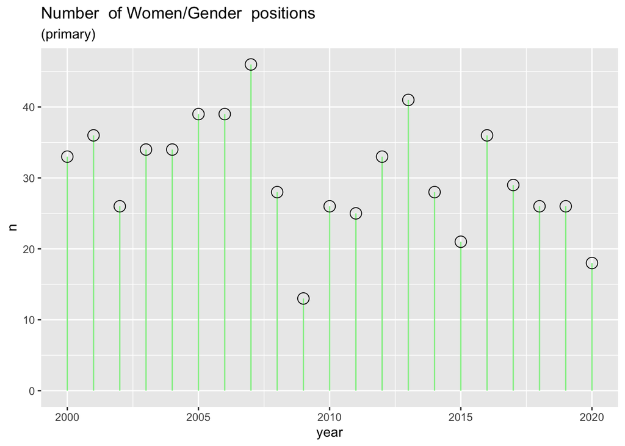

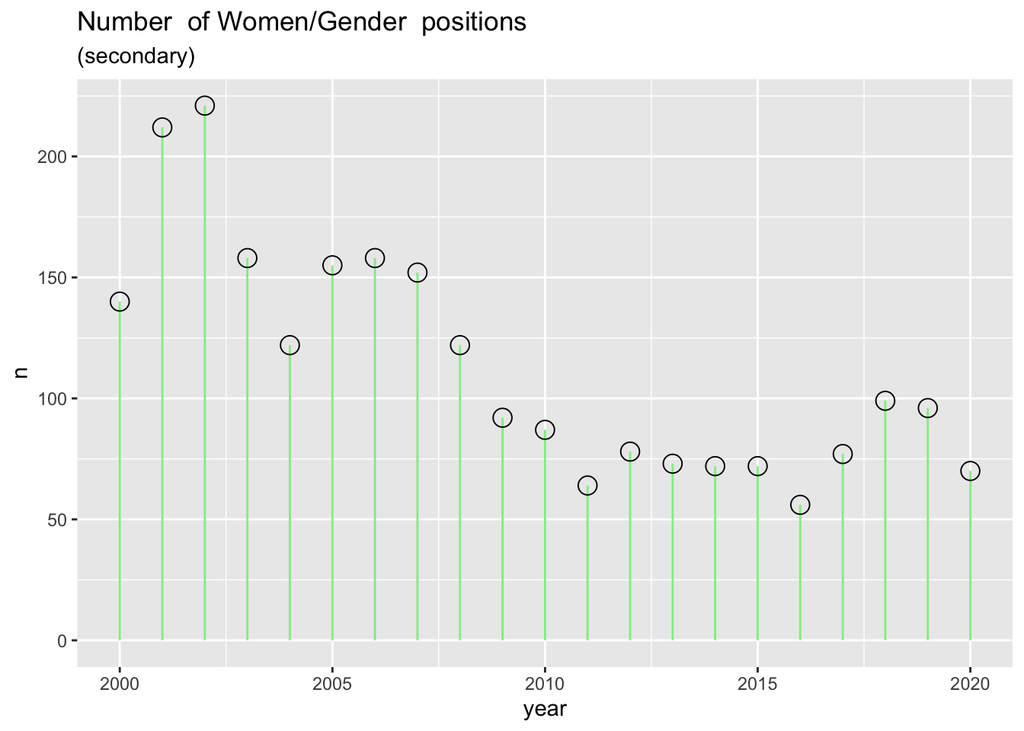

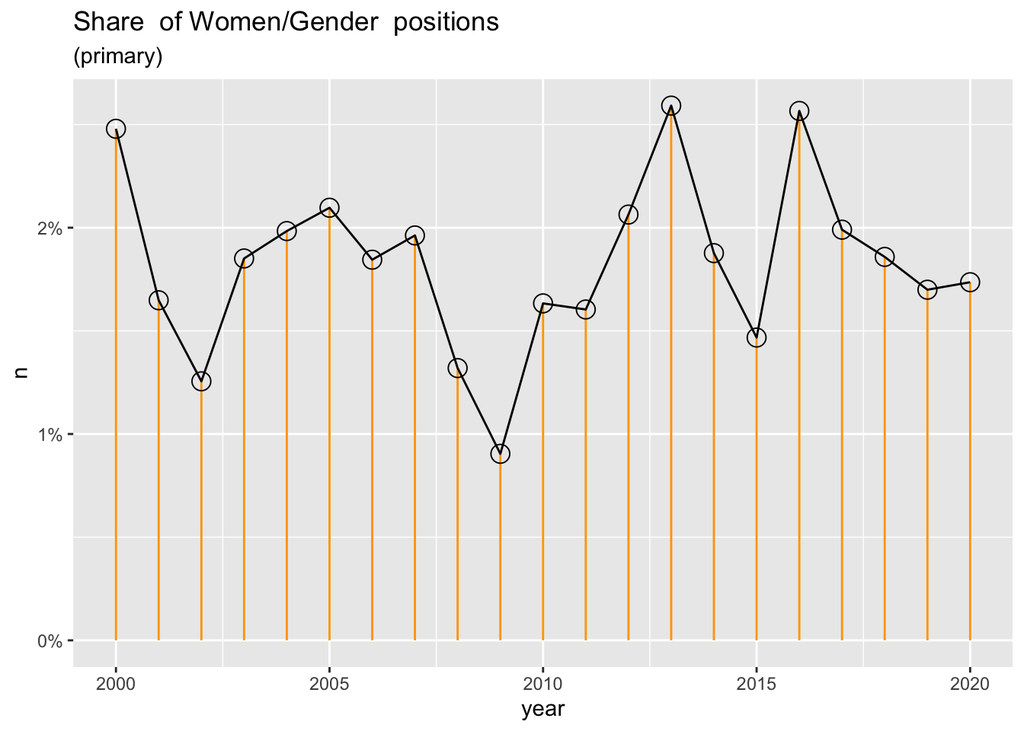

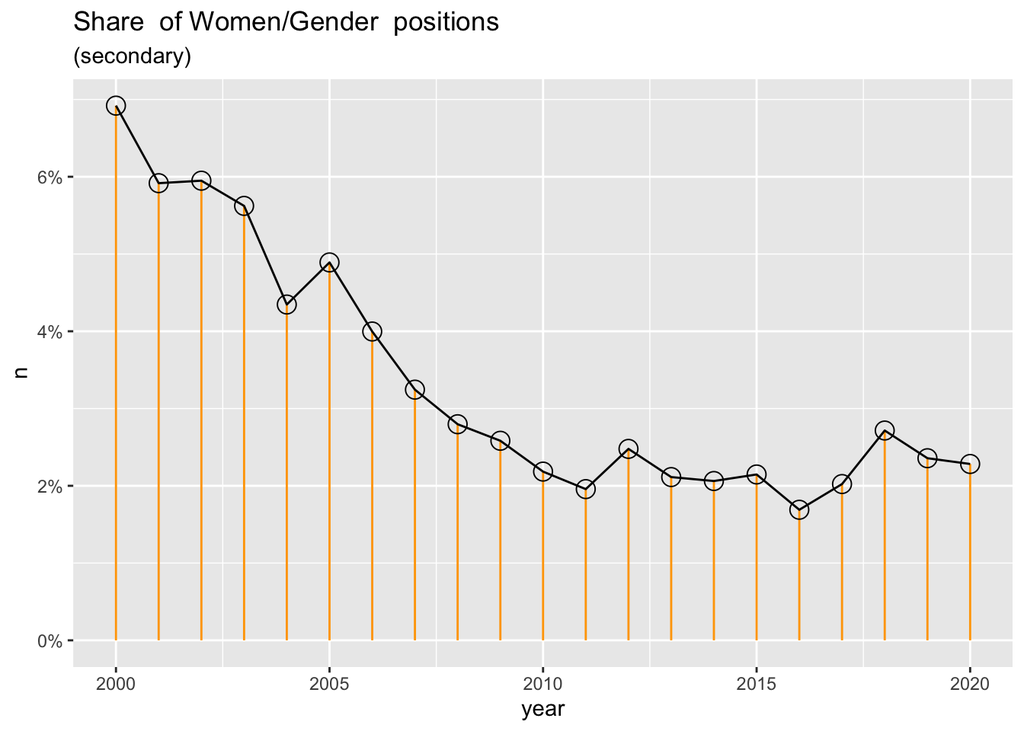

## Positions posted by continent and country

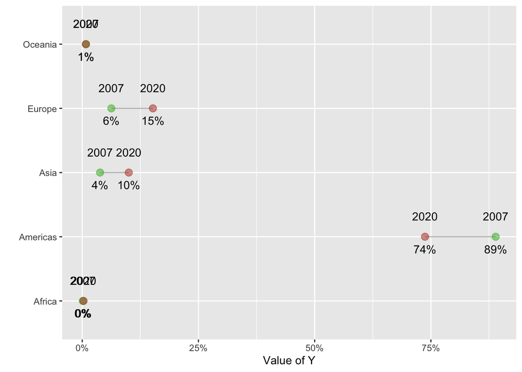